# NYC Flight - Part 1

Amruta Jadhav

#### Basic R Programming

Write a function, `calculate_bmi` to calculate a person’s body mass index, when given two input parameters, 1) weight in pounds and 2) height in inches.

*NOTE: You would have to go to external sources to find the formula of bmi.* In your response, before presenting your code for the function, tell us your official reference for the BMI formula.

##### **Insert Response first**

##### **1. What is BMI?**

Body mass index (BMI) is a person’s weight in kilograms divided by the square of height in meters. BMI is an inexpensive and easy screening method for weight category—underweight, healthy weight, overweight, and obesity. If pounds and inches are used, a conversion factor of 703 (kg/m2)/(lb/in2) must be applied.

##### **2. What is the formula to calculate BMI?**

BMI = (weight in lbs/ (height in inches)<sup>2</sup>) x 703

##### **References:**

(September 17, 2020).*Centers for Diseases Control and Prevention.* [Reference Link](https://www.cdc.gov/healthyweight/assessing/bmi/index.html)

(n.d). *Body Mass Index from Wikipedia.* Reference Link

##### **Insert code. Your code should appear within R Code Chunks.**

```r
calculate_bmi <- function(weight_lbs, height_in) {
  return((weight_lbs/(height_in)^2) * 703)
}


calculate_bmi(144, 68)
```

```
## [1] 21.89273
```

```r
calculate_bmi(150, 64)
```

```
## [1] 25.74463
```

#### Exploring the NYC Flights Data

In this problem set, we will use the data on all flights that departed NYC (i.e. JFK, LGA or EWR) in 2013. You can find this data in the `nycflights13` R package.

##### **Setup**

Installing the following R packages. The data itself resides in package *nycflights13*.

```r
# Load standard libraries
library(tidyverse)
library('nycflights13')
library(ggplot2)
```

```r
# Load the nycflights13 library which includes data on all
# fights departing NYC
data(flights)

# Note the data itself is called flights, we will make it into a
# local df for readability
flights <- tbl_df(flights)

# Look at the help file for information about the data & flights
summary(flights)
```

```
##       year          month             day           dep_time    sched_dep_time
##  Min.   :2013   Min.   : 1.000   Min.   : 1.00   Min.   :   1   Min.   : 106
##  1st Qu.:2013   1st Qu.: 4.000   1st Qu.: 8.00   1st Qu.: 907   1st Qu.: 906
##  Median :2013   Median : 7.000   Median :16.00   Median :1401   Median :1359
##  Mean   :2013   Mean   : 6.549   Mean   :15.71   Mean   :1349   Mean   :1344
##  3rd Qu.:2013   3rd Qu.:10.000   3rd Qu.:23.00   3rd Qu.:1744   3rd Qu.:1729
##  Max.   :2013   Max.   :12.000   Max.   :31.00   Max.   :2400   Max.   :2359
##                                                  NA's   :8255
##    dep_delay          arr_time    sched_arr_time   arr_delay
##  Min.   : -43.00   Min.   :   1   Min.   :   1   Min.   : -86.000
##  1st Qu.:  -5.00   1st Qu.:1104   1st Qu.:1124   1st Qu.: -17.000
##  Median :  -2.00   Median :1535   Median :1556   Median :  -5.000
##  Mean   :  12.64   Mean   :1502   Mean   :1536   Mean   :   6.895
##  3rd Qu.:  11.00   3rd Qu.:1940   3rd Qu.:1945   3rd Qu.:  14.000
##  Max.   :1301.00   Max.   :2400   Max.   :2359   Max.   :1272.000
##  NA's   :8255      NA's   :8713                  NA's   :9430
##    carrier              flight       tailnum             origin
##  Length:336776      Min.   :   1   Length:336776      Length:336776
##  Class :character   1st Qu.: 553   Class :character   Class :character
##  Mode  :character   Median :1496   Mode  :character   Mode  :character
##                     Mean   :1972
##                     3rd Qu.:3465
##                     Max.   :8500
##
##      dest              air_time        distance         hour
##  Length:336776      Min.   : 20.0   Min.   :  17   Min.   : 1.00
##  Class :character   1st Qu.: 82.0   1st Qu.: 502   1st Qu.: 9.00
##  Mode  :character   Median :129.0   Median : 872   Median :13.00
##                     Mean   :150.7   Mean   :1040   Mean   :13.18
##                     3rd Qu.:192.0   3rd Qu.:1389   3rd Qu.:17.00
##                     Max.   :695.0   Max.   :4983   Max.   :23.00
##                     NA's   :9430
##      minute        time_hour
##  Min.   : 0.00   Min.   :2013-01-01 05:00:00
##  1st Qu.: 8.00   1st Qu.:2013-04-04 13:00:00
##  Median :29.00   Median :2013-07-03 10:00:00
##  Mean   :26.23   Mean   :2013-07-03 05:22:54
##  3rd Qu.:44.00   3rd Qu.:2013-10-01 07:00:00
##  Max.   :59.00   Max.   :2013-12-31 23:00:00
##
```

##### **(a) Importing Data**

Load the data and describe in a short paragraph how the data was collected and what each variable represents.

##### Solution:

NYC flight data contains the details of all the flights that departed from NYC (JFK, LGA, EWR) in 2013. The data is stored in a package. [Link to the package](https://cran.r-project.org/web/packages/nycflights13/index.html). The dimension of the data frame is 336776 x 19.

Some variables that are provided and would be useful for data analysis are: departure & arrival times, scheduled departure & arrival times, delays in departure & arrival, aircraft carrier, distance traveled, etc. To get the idea of the data variables & values, I have used the head & tail of the data frame.

```r
str(flights)      #This will give all necessary details about data
```

```
## tibble [336,776 x 19] (S3: tbl_df/tbl/data.frame)
##  $ year          : int [1:336776] 2013 2013 2013 2013 2013 2013 2013 2013 2013 2013 ...
##  $ month         : int [1:336776] 1 1 1 1 1 1 1 1 1 1 ...
##  $ day           : int [1:336776] 1 1 1 1 1 1 1 1 1 1 ...
##  $ dep_time      : int [1:336776] 517 533 542 544 554 554 555 557 557 558 ...
##  $ sched_dep_time: int [1:336776] 515 529 540 545 600 558 600 600 600 600 ...
##  $ dep_delay     : num [1:336776] 2 4 2 -1 -6 -4 -5 -3 -3 -2 ...
##  $ arr_time      : int [1:336776] 830 850 923 1004 812 740 913 709 838 753 ...
##  $ sched_arr_time: int [1:336776] 819 830 850 1022 837 728 854 723 846 745 ...
##  $ arr_delay     : num [1:336776] 11 20 33 -18 -25 12 19 -14 -8 8 ...
##  $ carrier       : chr [1:336776] "UA" "UA" "AA" "B6" ...
##  $ flight        : int [1:336776] 1545 1714 1141 725 461 1696 507 5708 79 301 ...
##  $ tailnum       : chr [1:336776] "N14228" "N24211" "N619AA" "N804JB" ...
##  $ origin        : chr [1:336776] "EWR" "LGA" "JFK" "JFK" ...
##  $ dest          : chr [1:336776] "IAH" "IAH" "MIA" "BQN" ...
##  $ air_time      : num [1:336776] 227 227 160 183 116 150 158 53 140 138 ...
##  $ distance      : num [1:336776] 1400 1416 1089 1576 762 ...
##  $ hour          : num [1:336776] 5 5 5 5 6 5 6 6 6 6 ...
##  $ minute        : num [1:336776] 15 29 40 45 0 58 0 0 0 0 ...
##  $ time_hour     : POSIXct[1:336776], format: "2013-01-01 05:00:00" "2013-01-01 05:00:00" ...
```

```r
colnames(flights) #Gives all the column names in the table
```

```
##  [1] "year"           "month"          "day"            "dep_time"
##  [5] "sched_dep_time" "dep_delay"      "arr_time"       "sched_arr_time"
##  [9] "arr_delay"      "carrier"        "flight"         "tailnum"
## [13] "origin"         "dest"           "air_time"       "distance"
## [17] "hour"           "minute"         "time_hour"
```

```r
head(flights)     #Give first few rows of dataset
```

```
## # A tibble: 6 x 19
##    year month   day dep_time sched_dep_time dep_delay arr_time sched_arr_time
##   <int> <int> <int>    <int>          <int>     <dbl>    <int>          <int>
## 1  2013     1     1      517            515         2      830            819
## 2  2013     1     1      533            529         4      850            830
## 3  2013     1     1      542            540         2      923            850
## 4  2013     1     1      544            545        -1     1004           1022
## 5  2013     1     1      554            600        -6      812            837
## 6  2013     1     1      554            558        -4      740            728
## # ... with 11 more variables: arr_delay <dbl>, carrier <chr>, flight <int>,
## #   tailnum <chr>, origin <chr>, dest <chr>, air_time <dbl>, distance <dbl>,
## #   hour <dbl>, minute <dbl>, time_hour <dttm>
```

```r
tail(flights)     #Give last rows of the dataset
```

```
## # A tibble: 6 x 19
##    year month   day dep_time sched_dep_time dep_delay arr_time sched_arr_time
##   <int> <int> <int>    <int>          <int>     <dbl>    <int>          <int>
## 1  2013     9    30       NA           1842        NA       NA           2019
## 2  2013     9    30       NA           1455        NA       NA           1634
## 3  2013     9    30       NA           2200        NA       NA           2312
## 4  2013     9    30       NA           1210        NA       NA           1330
## 5  2013     9    30       NA           1159        NA       NA           1344
## 6  2013     9    30       NA            840        NA       NA           1020
## # ... with 11 more variables: arr_delay <dbl>, carrier <chr>, flight <int>,
## #   tailnum <chr>, origin <chr>, dest <chr>, air_time <dbl>, distance <dbl>,
## #   hour <dbl>, minute <dbl>, time_hour <dttm>
```

##### **(b) Inspecting Data**

Perform a basic inspection of the data and discuss what you find. Inspections may involve asking the following questions (the list is not inclusive, you may well ask other questions):

- How many distinct flights do we have in the dataset?
- How many missing values are there in each variable?
- Do you see any unreasonable values? *Hint: Check out min, max and range functions.*

##### Solution:

- Calculated the number of distinct flights based on the flights number. So there are 3844 unique flight numbers in the data frame.
- There are total 16 different carriers that have flights through out the year and I have used the table function to show their frequency
- The majority of missing values can be found in the dep_time, dep_delay, arr_time, arr_delay, tailnum and air_time columns. Remaining columns do not have any missing values. Compared to the dataset size (336776) these missing values (app. 9000 in each above mentioned col) are fairly low
- Through the summary function we can know the min, max and range of all the columns in the data frame. The min, max and range of the year, month, day, hour, minute and time_hour column are standard and reasonable. In case of other columns the min, max & range looks fairly reliable.

```r
#Number of distinct flights in the dataset
table(flights$carrier)
```

```
##
##    9E    AA    AS    B6    DL    EV    F9    FL    HA    MQ    OO    UA    US
## 18460 32729   714 54635 48110 54173   685  3260   342 26397    32 58665 20536
##    VX    WN    YV
##  5162 12275   601
```

```r
flightNums <- as.data.frame(table(flights$flight))
str(flightNums)
```

```
## 'data.frame':    3844 obs. of  2 variables:
##  $ Var1: Factor w/ 3844 levels "1","2","3","4",..: 1 2 3 4 5 6 7 8 9 10 ...
##  $ Freq: int  701 51 631 393 324 210 237 236 153 61 ...
```

```r
#Finding the number of missing values
colSums(is.na(flights))
```

```
##           year          month            day       dep_time sched_dep_time
##              0              0              0           8255              0
##      dep_delay       arr_time sched_arr_time      arr_delay        carrier
##           8255           8713              0           9430              0
##         flight        tailnum         origin           dest       air_time
##              0           2512              0              0           9430
##       distance           hour         minute      time_hour
##              0              0              0              0
```

```r
#Finding min, max & range
summary(flights)
```

```
##       year          month             day           dep_time    sched_dep_time
##  Min.   :2013   Min.   : 1.000   Min.   : 1.00   Min.   :   1   Min.   : 106
##  1st Qu.:2013   1st Qu.: 4.000   1st Qu.: 8.00   1st Qu.: 907   1st Qu.: 906
##  Median :2013   Median : 7.000   Median :16.00   Median :1401   Median :1359
##  Mean   :2013   Mean   : 6.549   Mean   :15.71   Mean   :1349   Mean   :1344
##  3rd Qu.:2013   3rd Qu.:10.000   3rd Qu.:23.00   3rd Qu.:1744   3rd Qu.:1729
##  Max.   :2013   Max.   :12.000   Max.   :31.00   Max.   :2400   Max.   :2359
##                                                  NA's   :8255
##    dep_delay          arr_time    sched_arr_time   arr_delay
##  Min.   : -43.00   Min.   :   1   Min.   :   1   Min.   : -86.000
##  1st Qu.:  -5.00   1st Qu.:1104   1st Qu.:1124   1st Qu.: -17.000
##  Median :  -2.00   Median :1535   Median :1556   Median :  -5.000
##  Mean   :  12.64   Mean   :1502   Mean   :1536   Mean   :   6.895
##  3rd Qu.:  11.00   3rd Qu.:1940   3rd Qu.:1945   3rd Qu.:  14.000
##  Max.   :1301.00   Max.   :2400   Max.   :2359   Max.   :1272.000
##  NA's   :8255      NA's   :8713                  NA's   :9430
##    carrier              flight       tailnum             origin
##  Length:336776      Min.   :   1   Length:336776      Length:336776
##  Class :character   1st Qu.: 553   Class :character   Class :character
##  Mode  :character   Median :1496   Mode  :character   Mode  :character
##                     Mean   :1972
##                     3rd Qu.:3465
##                     Max.   :8500
##
##      dest              air_time        distance         hour
##  Length:336776      Min.   : 20.0   Min.   :  17   Min.   : 1.00
##  Class :character   1st Qu.: 82.0   1st Qu.: 502   1st Qu.: 9.00
##  Mode  :character   Median :129.0   Median : 872   Median :13.00
##                     Mean   :150.7   Mean   :1040   Mean   :13.18
##                     3rd Qu.:192.0   3rd Qu.:1389   3rd Qu.:17.00
##                     Max.   :695.0   Max.   :4983   Max.   :23.00
##                     NA's   :9430
##      minute        time_hour
##  Min.   : 0.00   Min.   :2013-01-01 05:00:00
##  1st Qu.: 8.00   1st Qu.:2013-04-04 13:00:00
##  Median :29.00   Median :2013-07-03 10:00:00
##  Mean   :26.23   Mean   :2013-07-03 05:22:54
##  3rd Qu.:44.00   3rd Qu.:2013-10-01 07:00:00
##  Max.   :59.00   Max.   :2013-12-31 23:00:00
##
```

##### **(c) Formulating Questions**

Consider the NYC flights data. Formulate two motivating questions you want to explore using this data. Describe why these questions are interesting and how you might go about answering them.

Example questions:

- Which airport, JFK or LGA, experience more delays?
- What was the worst day to fly out?
- Are there seasonal patterns?

##### Solution:

The questions that I will be answering through my analysis are:

1. Which carrier has the highest number of flights per month? By answering this question we can know which aircraft carrier people of NYC prefer.
2. Which carrier has experienced maximum and minimum delays? The maximum & minimum number of delays can help us decide the aircraft carrier to avoid.
3. Which airport EWR, JFK or LGA, experience more delays? Delays can also happen due to improper management at the airport.
4. What is the number of flights departing from each of the three airports? This will help us know which is the busiest airport in New york city.
5. Are there seasonal patterns? By answering this question I can find out how seasonal changes affects the travel.

##### **(d) Exploring Data**

For each of the questions you proposed in Problem 1c, perform an exploratory data analysis designed to address the question. Produce visualizations (graphics or tables) to answer your question. * You need to explore the data from the point of view of the questions * Depending on the question, you would need to provide precise definition. For example, what does “more delays” mean. * At a minimum, you should produce two visualizations (graphics or tables) related to each question. Be sure to describe what the visuals show and how they speak to your question of interest.

##### Solution:

```
1. Which carrier has the highest number of flights per month?
```

Through the plots we can see that United Airline has the highest number of departing flights in the year 2013. The bar graph grid gives us the clearer picture of frequency of the flights and carrier monthly. We are able to compare all the carrier graphs easily.

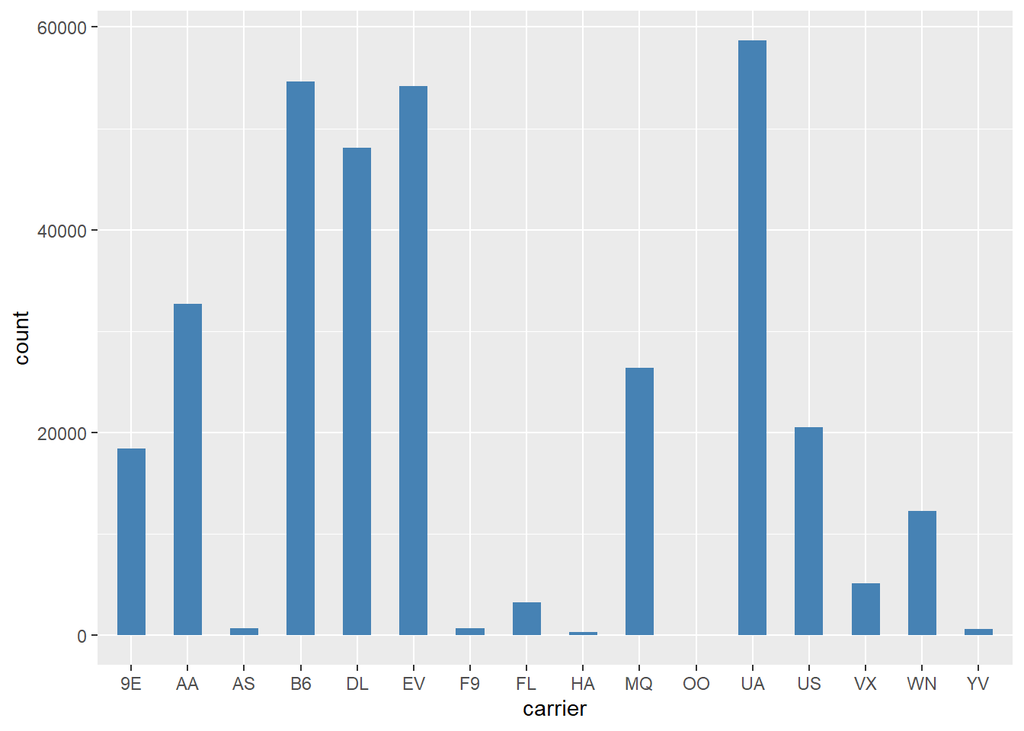

```r
# Total flight count throughout the year by carrier
ggplot(data = flights, aes(x = carrier)) +
  geom_bar(fill = "steelblue", width = 0.5)
```

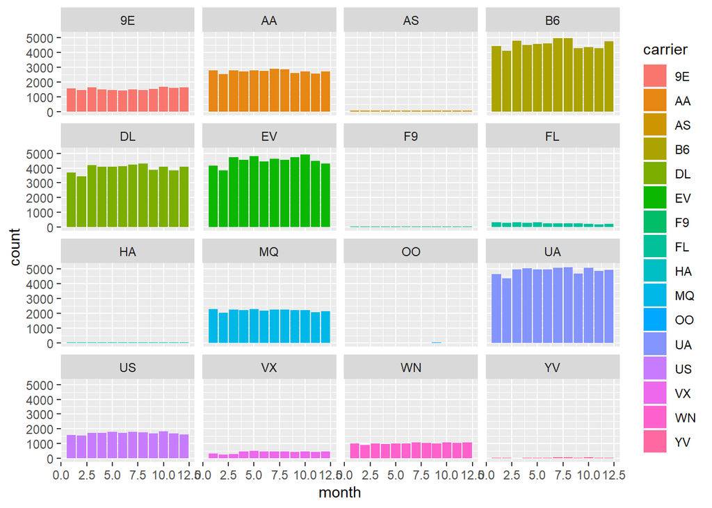

```r
#Flight count by carrier & month
ggplot(flights) +
  geom_bar(aes(x = month, fill = carrier)) +
  facet_wrap(~ carrier, nrow = 4)
```

2. Which airport, JFK or LGA, experience more delays?
3. Which carrier has experienced maximum and minimum delays?

The point plot gives us the idea that majority of the delays have occurred at the LaGuardia Airport. We can also say by looking at the months that delay have occurred during the summer months. The reason for this might be that more people go on vacation in summers so more number of flights must be operating. By looking at the box plot we can predict that Skywest Airlines(OO) has a high average delays. Whereas, Hawaiian airlines has very low average delays.

```r
# Creating a new dataframe 'df_delay' to find the monthly average
# delays

df_delay <- flights %>%
  select(origin, carrier, dep_delay, month) %>%
  filter(dep_delay > 0) %>%
  na.omit()

# Average departure delay by month and origin airport

dep_delay_bymonth <- df_delay %>%

  group_by(origin, month) %>%

  summarize(avg_dep_delay = mean(dep_delay))
```

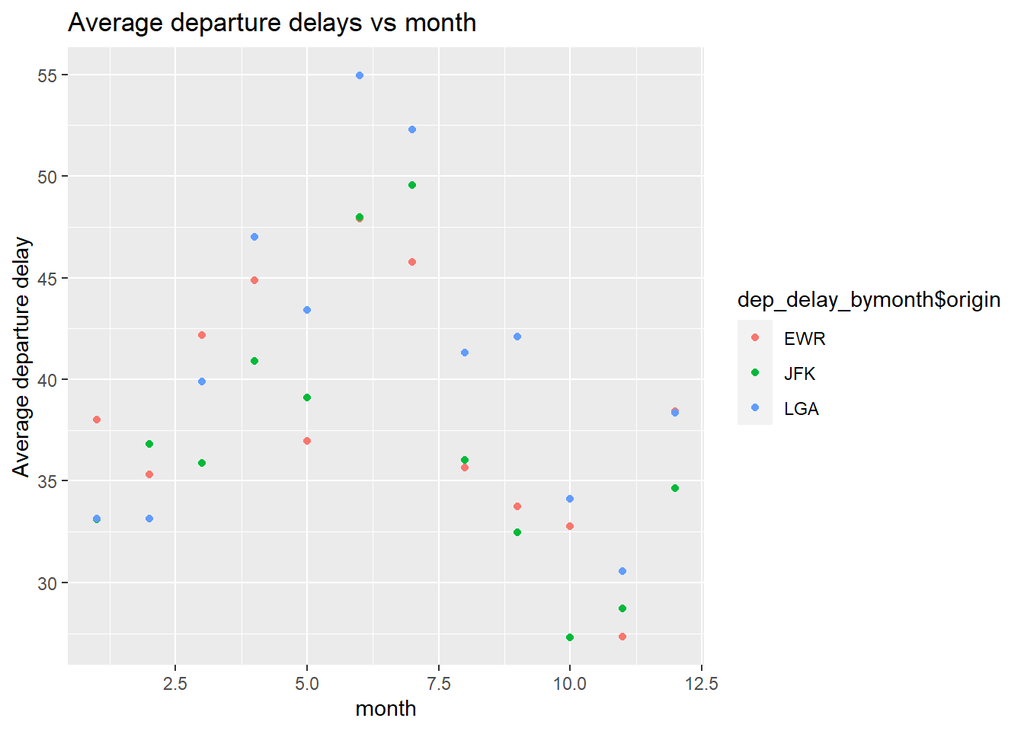

```r
# Plotting the average departure delay vs month graph

ggplot(data = dep_delay_bymonth,
        aes(x = dep_delay_bymonth$month,
        y = dep_delay_bymonth$avg_dep_delay)) +
        geom_point(aes(color = dep_delay_bymonth$origin)) +
        labs(title = "Average departure delays vs month",
        x = "month", y = "Average departure delay") +
        scale_fill_discrete(name = "Origin airport")
```

```r
# Average departure delay by carrier
dep_delay_bycarrier <- df_delay %>%

  group_by(carrier, month) %>%

  summarize (avg_dep_delay = mean(dep_delay))
```

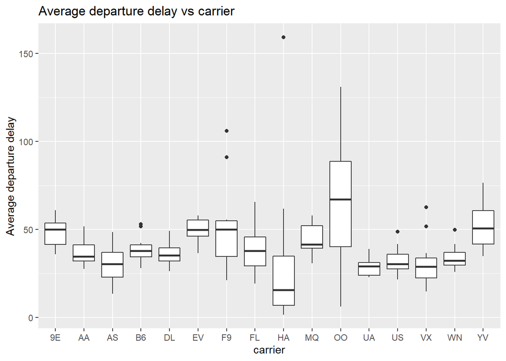

```r
ggplot(data = dep_delay_bycarrier,
       aes(x = dep_delay_bycarrier$carrier,
           y = dep_delay_bycarrier$avg_dep_delay)) +
  geom_boxplot() + labs(title = "Average departure delay vs carrier", x = "carrier", y = "Average departure delay")
```

4. What distribution of the flights over the 3 departing airports?
5. Are there seasonal patterns?

The bar graph depicts that Newark(EWR) airport has the highest number of fights flying throughout the year. However, JFK & LGA are just slightly below EWR. Through the frequency of flights for each month in 2013, it is clear that it was highest during the july and august i.e the summer months. Beside, these numbers are lowest in february and january i.e the winter months. So, it clear that people travel more in the summer months.

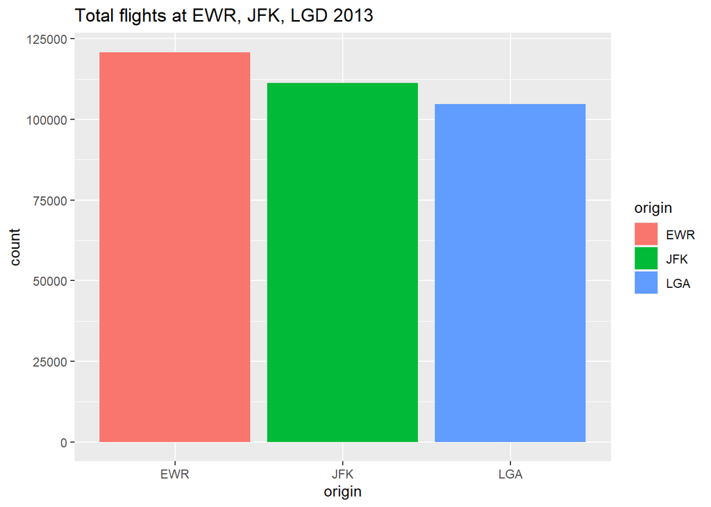

```r
#Number of flights at the origin airport

ggplot(data = flights) +
  geom_bar(aes(x = origin, fill = origin)) +
  labs(title = "Total flights at EWR, JFK, LGD 2013")
```

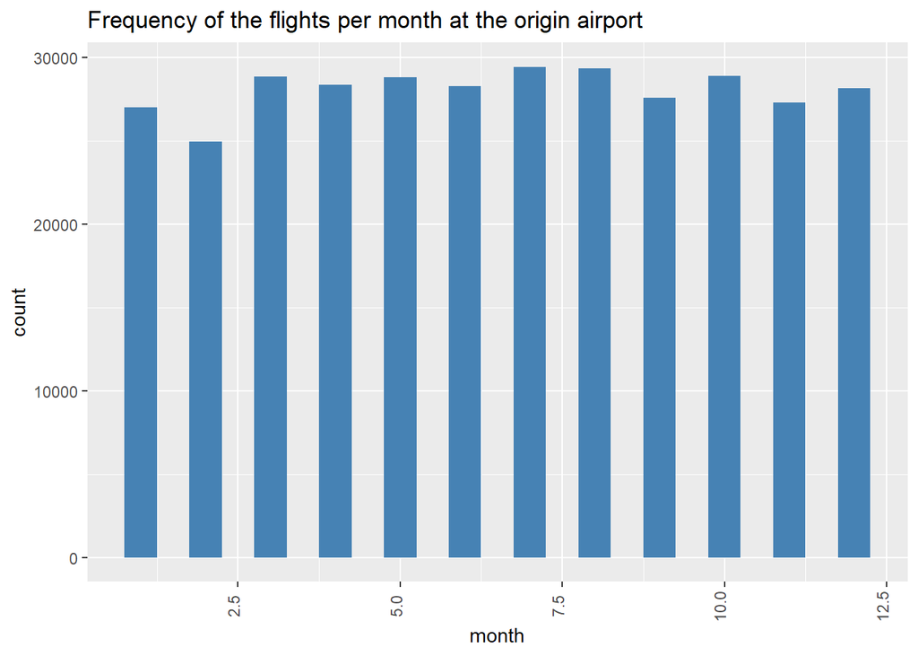

```r
#Frequency of flight as per month

ggplot(data = flights, aes(month)) +
  geom_bar(stat = "count",width = 0.5, fill = "steelblue") +
  theme(axis.text.x = element_text(angle=90, vjust=0.1)) +
  labs(title = "Frequency of the flights per month at the origin airport")
```